# Ezekiel_ESS______New species added

```r
combined_plot <- Calibration_plot_yield + Calibration_plot_biomass +
  plot_layout(nrow = 1)
```

Plot Observed vs model error calibration period

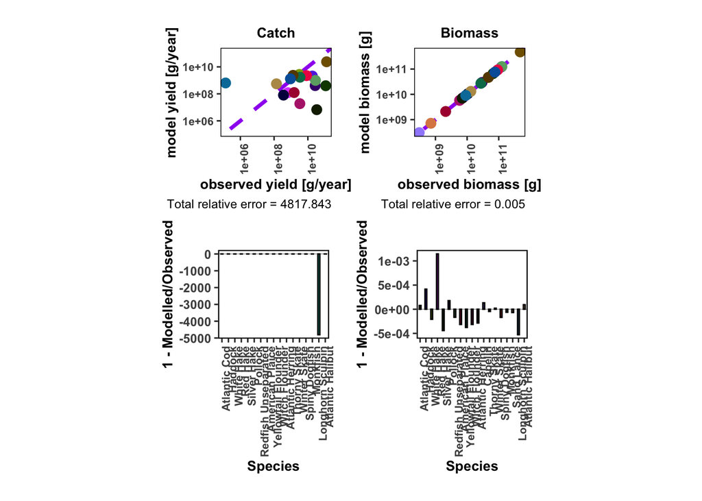

```r
library(ggplot2)
library(forcats)
library(patchwork)

# ------------------------------------------------------------
# Shared colour palette for 16 species
# ------------------------------------------------------------
species_colours <- c(
  "#815f00", "#6237e2", "#8da600", "#de53ff", "#0e4300",
  "#430079", "#6caa72", "#ee0053", "#007957", "#b42979",
  "#142300", "#a08dfb", "#644500", "#00b4d8", "#e76f51",
  "#2a9d8f", "#f4a261", "#457b9d", "#e9c46a"
)

# ------------------------------------------------------------
# Shared theme
# ------------------------------------------------------------
calibration_theme <- theme_bw() +
  theme(
    axis.text.x     = element_text(angle = 90, hjust = 1, vjust = 1, face = "bold", size = 8),
    axis.text.y     = element_text(face = "bold", size = 9),
    panel.grid      = element_blank(),
    panel.border    = element_rect(color = "black", linewidth = 0.8),
    axis.title      = element_text(size = 10, face = "bold"),
    legend.position = "none",
    panel.spacing   = unit(0.5, "lines"),
    plot.margin     = unit(c(0.5, 0.5, 0.5, 0.2), "cm"),
    aspect.ratio    = 0.8)

# ------------------------------------------------------------
# 1. Yield plot
# ------------------------------------------------------------
Calibration_pb_yield <- plotYieldObservedVsModel(params, ratio = FALSE, labels = FALSE, return_data = TRUE)

pb_yield <- mean(1 - Calibration_pb_yield$ratio, na.rm = TRUE)

Calibration_plot_Y <- ggplot(
  Calibration_pb_yield,
  aes(x = species, y = 1 - ratio, fill = species)) +
  geom_bar(stat = "identity", position = "dodge", width = 0.3, color = "black") +
  scale_fill_manual(values = species_colours) +
  geom_hline(yintercept = 0, color = "black", linewidth = 0.1) +
  annotate("text", x = Inf, y = Inf,label = expression(bold("(c)")),
  parse = TRUE, size = 3, hjust = 21.5, vjust = 2.1) +
  labs(x = "Species", y = "1 - Modelled/Observed") +
  calibration_theme

# ------------------------------------------------------------
# 2. Biomass plot
# ------------------------------------------------------------
Calibration_pb_biomass <- plotBiomassObservedVsModel(
  params, ratio = FALSE, labels = FALSE, return_data = TRUE)

pb_biomass <- mean(1 - Calibration_pb_biomass$ratio, na.rm = TRUE)

Calibration_plot_B <- ggplot(
  Calibration_pb_biomass,
  aes(x = species, y = 1 - ratio, fill = species)) +
  geom_bar(stat = "identity", position = "dodge", width = 0.3, color = "black") +
  scale_fill_manual(values = species_colours) +
  geom_hline(yintercept = 0, color = "black", linewidth = 0.1) +
  annotate("text",
    x     = length(unique(Calibration_pb_biomass$species)) + 0.5,
    y     = max(1 - Calibration_pb_biomass$ratio, na.rm = TRUE),
    label = expression(bold("(d)")),
    parse = TRUE, size = 3, hjust = 20.5, vjust = 1.1
  ) +
  labs(x = "Species", y = "1 - Modelled/Observed") +
  calibration_theme

# ------------------------------------------------------------
# 3. Combined plot
# ------------------------------------------------------------
Calibration_plot <- combined_plot / (Calibration_plot_Y + Calibration_plot_B)
Calibration_plot
```

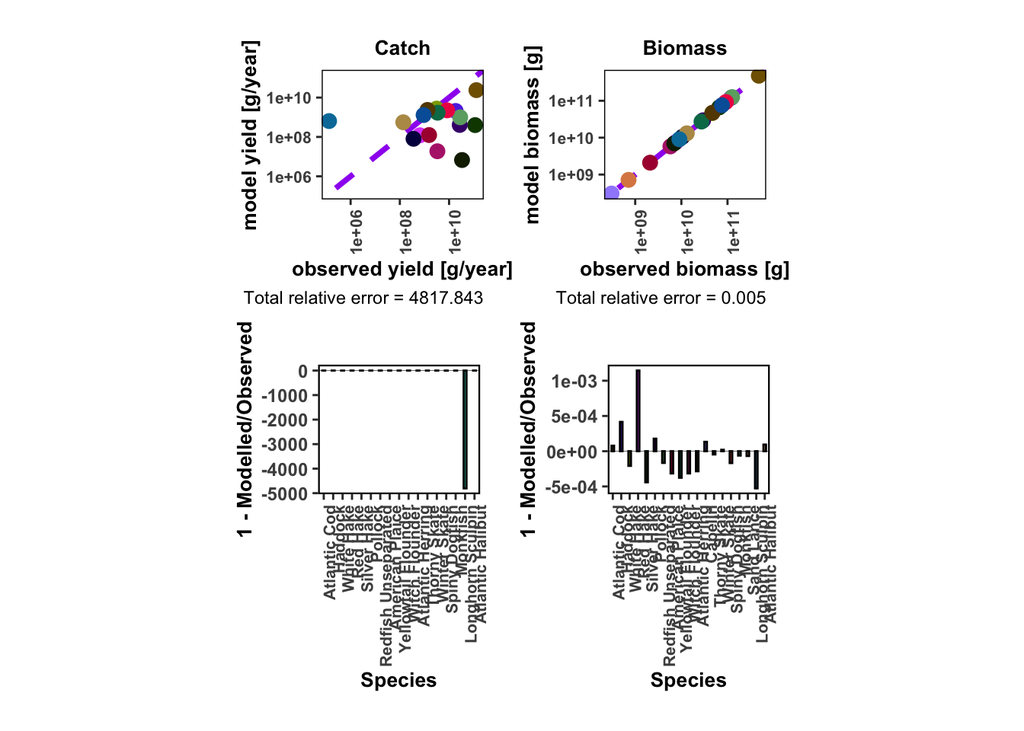

```r
ggsave(filename = paste0(save_dir, "Calibration_plot.jpeg"), plot = Calibration_plot,
       width = 11,
       height = 8.5,
       units = "in",
       dpi = 400)
Calibration_plot
```

## Check plots with time series effort forcing on

Run the model with changing fishing through time

```r
fishing_history = readRDS("Ess_data/effort_by_gear.rds")
effort<-fishing_history[as.character("1978":"2024"),]

params_spin<-projectToSteady(params,effort=initial_effort(params),t_max=100)
```

```
## Convergence was achieved in 1.5 years.
```

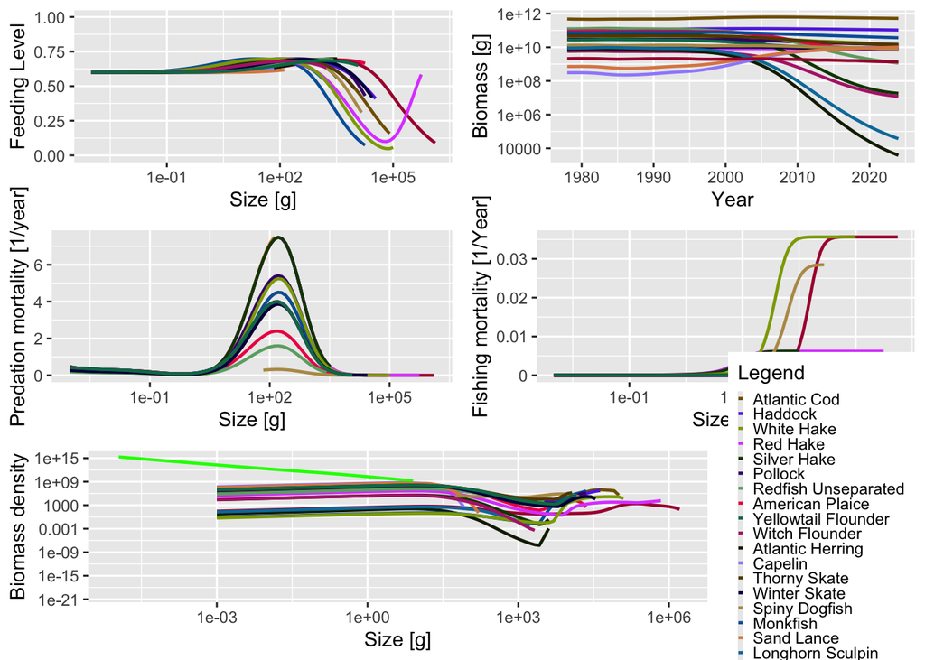

```r
sim<- project(params_spin, effort = effort)
plot(sim)
```

# Exploratory Run of Projection through Time

Now, assess how the full model looks compared with time series data in the reference period only. Should calculate some statistical goodness of fit metrics here

Get modelled biomass, excluding sizes < biomass_cutoff g to be consistent with the survey biomasses

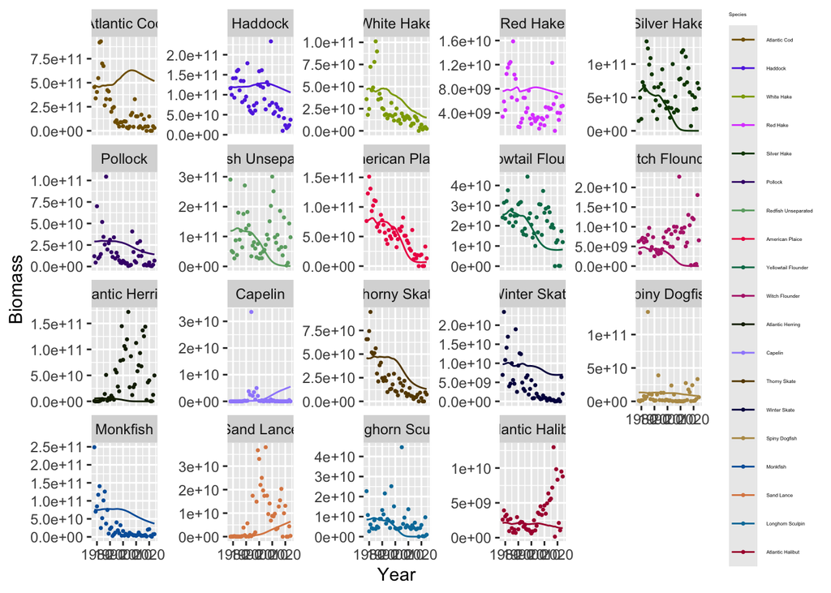

```r
biomass_sim_base<-getBiomass(sim,min_w=10)
biomass_sim_base<-melt(biomass_sim_base,id.vars=1)
names(biomass_sim_base)<-c("Year", "Species","Biomass")


ggplot(biomass_sim_base,aes(x = Year, y = Biomass, group = Species))+
    geom_line(data=biomass_sim_base,aes(colour = Species)) +
    facet_wrap(~Species,scales="free_y") +
  geom_point(data=filter(biomass_ts),aes(x = Year, y = (Biomass), colour = Species),size=0.5)+
    theme(legend.title = element_text( size=3), legend.text=element_text(size=3))+
    scale_colour_manual(values=params@linecolour) # +
```

```r
 # xlim(1970,2010)
```

Make plots  
plot yields

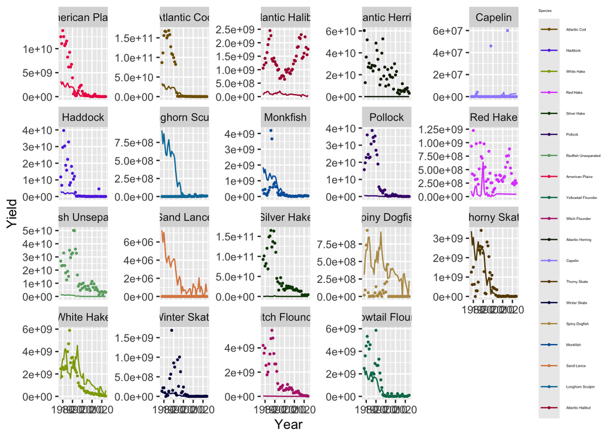

```r
yield_sim_base<- plotYieldGear(sim, return_data = T)

#already melted
#yield_sim_base<-melt(yield_sim_base,id.vars=1)
#names(yield_sim_base)<-c("Year", "Species","Yield")

ggplot(filter(yield_sim_base,Species!="Sand Lances"),aes(x = Year, y = Yield, group = Species))+
    geom_line(data=yield_sim_base,aes(colour = Species)) +
    facet_wrap(~Species,scales="free_y") +
  geom_point(data=filter(yield_ts,Species!="Sand Lances"),aes(x = Year, y = (Yield), colour = Species),size=0.5)+
    #geom_point(data= yield_ts,Year<1986,aes(colour = Species), size=1) +
    theme(legend.title = element_text( size=3), legend.text=element_text(size=3))+
    scale_colour_manual(values=params@linecolour)
```

Test with Additional predation mortality on all spp Introduction of New gears (named: seal) params now include additional gear Seal diet roughly parameterised from info: https://waves-vagues.dfo-mpo.gc.ca/library-bibliotheque/41217913.pdf https://academic.oup.com/icesjms/article/71/6/1332/2835596 Bowen, W.D., 1.W. Lawson, and B. Beck. 1993. Seasonal and geographic variation in the species composition and sine sf prey consumed by grey seals (Halickoerus grypus) on the Scotian Shelf. Can. 1. Fish. Aquat. Sci. 50: 1768-1 778.

```r
gaussian_sizeweight <- function(w, species_params, w_opt, sigma, ...) {
  exp(-0.5 * ((log(w) - log(w_opt)) / sigma)^2)
}

seal_gear_params <- readRDS("Ess_data/seal_gear_params.RDS")
params_with_seal <- params
orig_gears <- gear_params(params)

orig_gears$w_opt <- NA
orig_gears$sigma <- NA

seal_gears <- seal_gear_params[, c("species", "gear", "sel_func",
                                    "catchability", "w_opt", "sigma")]
seal_gears$knife_edge_size <- NA

missing_cols <- setdiff(names(orig_gears), names(seal_gears))
for(col in missing_cols) seal_gears[[col]] <- NA
seal_gears <- seal_gears[, names(orig_gears)]

all_gears <- rbind(orig_gears, seal_gears)
gear_params(params_with_seal) <- all_gears
#save object for later use ( params with additional predation mortality)
saveRDS(params_with_seal,"Ess_data/params_with_seal_interaction.RDS")
```

[figure not shown]

```r
fishing_history = read.csv("Ess_data/effort_gear_with_seals.csv",row.names = 1)
effort<-fishing_history[as.character("1978":"2024"),]
effort_with_seal <- as.matrix(effort)

# Add Year column from row names
effort$Year <- as.numeric(rownames(effort))
# Convert to long format
effort_long <- effort %>%pivot_longer(cols = -Year, names_to = "Gear",values_to = "Effort" )
# Rename for publication-style labels
effort_long$Gear <- factor(
  effort_long$Gear,
  levels = c("Bottom_Trawl", "Fixed_Gear", "Pelagic", "Small_Mesh", "Seals"),
  labels = c("Bottom trawl", "Fixed gear", "Pelagic","Small mesh", "Grey seals"))
# facet plot
p <- ggplot(effort_long, aes(x = Year, y = Effort)) +
  geom_line(linewidth = 0.65, colour = "black") +
  facet_wrap(~ Gear, scales = "free_y", ncol = 2) +
  scale_x_continuous(
    breaks = c(1980, 1990, 2000, 2010, 2020),
    labels = c("1980", "1990", "2000", "2010", "2020"),
    expand = expansion(mult = c(0.02, 0.02))) +
  scale_y_continuous(expand = expansion(mult = c(0.02, 0.08))) +
  labs(x = NULL, y = "Relative effort (0–1)") +
  theme_classic(base_size = 11) +
  theme(
    strip.background = element_rect(fill = "white", colour = NA),
    strip.text        = element_text(face = "bold", size = 11, hjust = 0.5),
    axis.title.y      = element_text(face = "bold", size = 11, margin = margin(r = 8)),
    axis.text         = element_text(colour = "black", size = 9),
    axis.line         = element_line(colour = "black", linewidth = 0.4),
    axis.ticks        = element_line(colour = "black", linewidth = 0.4),
    panel.border      = element_rect(colour = "black", fill = NA, linewidth = 0.4),
    panel.spacing.x   = unit(1.2, "lines"),
    panel.spacing.y   = unit(0.8, "lines"),
    plot.margin       = margin(10, 15, 8, 10)
  )
p
```

```r
#save effort forcing matrix object for later use
#saveRDS(effort_with_seal,"Ess_data/new_effort_with_seal_matrix.RDS")
```

```r
#plotYieldGear(sim2,gears=c("Seals"))
```